# Super Bowl Prediction Analysis

Mason Hansen

2/2/2019

# Final Score Prediction and Outcome

[output not shown]

# Data Investigation

|  | n | mean | sd | min | max | range |
| --- | --- | --- | --- | --- | --- | --- |
| **Group 1: Standard NFL Game Stats** |  |  |  |  |  |  |
| Team_Score | 266 | 24.42 | 10.58 | 0.00 | 54.00 | 54.00 |
| Team_Passing | 266 | 242.55 | 83.83 | 20.00 | 462.00 | 442.00 |
| Team_Rushing | 266 | 117.41 | 55.14 | 14.00 | 323.00 | 309.00 |
| Total_Yards | 266 | 359.97 | 87.26 | 89.00 | 576.00 | 487.00 |
| Team_Turnovers | 266 | 1.25 | 1.15 | 0.00 | 5.00 | 5.00 |
| Opponent_Score | 266 | 22.24 | 9.82 | 0.00 | 51.00 | 51.00 |
| Opponent_Passing | 266 | 233.46 | 83.14 | 37.00 | 452.00 | 415.00 |
| Opponent_Rushing | 266 | 110.86 | 49.39 | 19.00 | 273.00 | 254.00 |
| Opponent_Total_yards | 266 | 344.32 | 89.02 | 119.00 | 576.00 | 457.00 |
| Opponent_Turnovers | 266 | 1.44 | 1.25 | 0.00 | 6.00 | 6.00 |
| Net_yards | 266 | 15.65 | 121.58 | -271.00 | 350.00 | 621.00 |
| Net_Score | 266 | 2.18 | 14.20 | -37.00 | 44.00 | 81.00 |
| Net_Turnovers | 266 | 0.20 | 1.78 | -5.00 | 5.00 | 10.00 |
| **Group 2: Engineered Performance Metrics** |  |  |  |  |  |  |
| Score_Percentile | 266 | 0.54 | 0.30 | 0.03 | 1.00 | 0.97 |
| Pass_percentile | 266 | 0.54 | 0.29 | 0.03 | 1.00 | 0.97 |
| rush_percentile | 266 | 0.52 | 0.30 | 0.03 | 1.00 | 0.97 |
| TotalYards_Percentile | 266 | 0.54 | 0.28 | 0.03 | 1.00 | 0.97 |
| TO_percentile | 266 | 0.63 | 0.30 | 0.00 | 0.97 | 0.97 |
| OppScore_Percentile | 266 | 0.47 | 0.28 | 0.03 | 1.00 | 0.97 |
| OppPass_Percentile | 266 | 0.50 | 0.29 | 0.03 | 1.00 | 0.97 |
| OppRush_Percentile | 266 | 0.50 | 0.28 | 0.03 | 1.00 | 0.97 |
| OppTotYd_Percentile | 266 | 0.49 | 0.29 | 0.03 | 1.00 | 0.97 |
| OppTO_Percentile | 266 | 0.58 | 0.32 | 0.00 | 0.97 | 0.97 |
| team_game_performance_metric | 266 | 0.55 | 0.19 | 0.09 | 0.96 | 0.86 |
| opp_game_performance_metric | 266 | 0.51 | 0.18 | 0.08 | 0.94 | 0.86 |
| favored_by_metric | 266 | 0.57 | 0.50 | 0.00 | 1.00 | 1.00 |
| upset_by_metric | 266 | 0.09 | 0.29 | 0.00 | 1.00 | 1.00 |

First step is to check the data for irregularities and possible outliers. A table of descriptive statistics is included. Only variable used later in the linear regression are included. Table of variables are split into two categories: Standard NFL game statistics, which include measurable statistics like Passing Yards, Rushing Yards, turnovers, etc…

The next group of variables is comprised of engineered variables calculated from the Standard NFL game statistics. The two groups of variables will be very similar, but the engineered variables have been tweaked slightly to improve accuracy. The engineered variables, also know as the performance metrics, are essentially a rank order percentile of all 32 teams performance. The main distinction in this new metric is that each category (e.g. Passing Yards) has been ranked against other teams’ Passing Yard performance, but only for the same game number. Essentially, the calculation of performance is isolated game by game and improves the accuracy of performance per game for each of the 32 teams in the data set

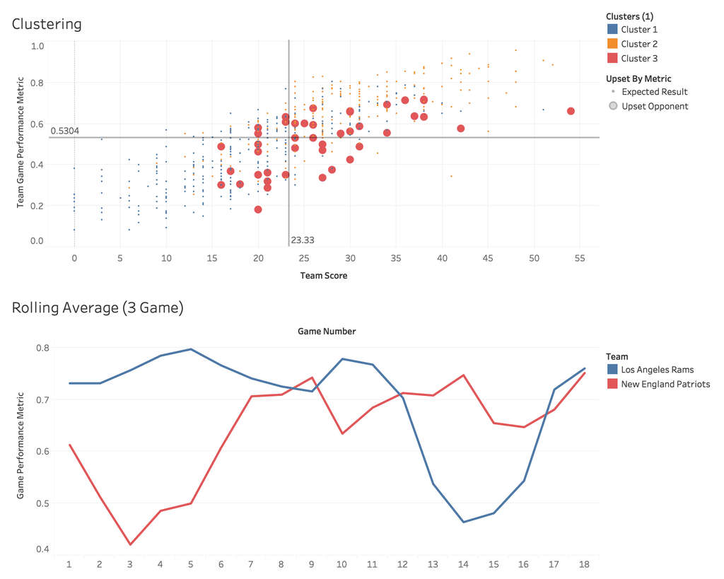

## Regression Analysis

### Linear Regression: Team Score

First Linear Model: This linear regression model was constructed using standard NFL game stats (Team / Opponent Passing Yards, Team / Opponent Rushing Yards and Team / Opponent Turnovers).

```
##
## Call:
## lm(formula = Team_Score ~ Team_Passing + Team_Rushing + Team_Turnovers +
##     Opponent_Passing + Opponent_Rushing + Opponent_Turnovers,
##     data = nfl_train[, 3:ncol(nfl_train)])
##
## Residuals:
##      Min       1Q   Median       3Q      Max
## -23.4270  -4.5032  -0.2857   4.1708  23.6994
##
## Coefficients:
##                     Estimate Std. Error t value Pr(>|t|)
## (Intercept)        -6.543550   2.225362  -2.940  0.00349 **
## Team_Passing        0.076501   0.004461  17.147  < 2e-16 ***
## Team_Rushing        0.089942   0.007118  12.635  < 2e-16 ***
## Team_Turnovers     -1.721389   0.300147  -5.735 2.04e-08 ***
## Opponent_Passing    0.006651   0.004529   1.468  0.14287
## Opponent_Rushing   -0.008500   0.007106  -1.196  0.23236
## Opponent_Turnovers  2.474770   0.291005   8.504 4.72e-16 ***
## ---
## Signif. codes:  0 '***' 0.001 '**' 0.01 '*' 0.05 '.' 0.1 ' ' 1
##
## Residual standard error: 6.71 on 366 degrees of freedom
## Multiple R-squared:  0.597,  Adjusted R-squared:  0.5904
## F-statistic: 90.36 on 6 and 366 DF,  p-value: < 2.2e-16
```

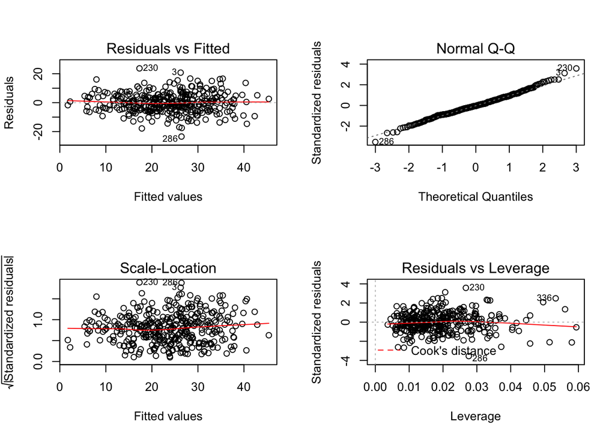

Our first linear model is significant at a 95% confidence level with p-value < 0.05. The model performs moderately well, with an R-sq value of 0.6. Model applied to both training and testing set. A summary of the predicted values from the testing set are as follows: 3.9863526, 16.3660799, 23.8778208, 23.340089, 30.0028318, 45.09168

Second Linear Regression Model: This linear regression model was constructed using engineered performance metrics (Team / Opponent Passing Performance, Team / Opponent Rushing Performance, Team / Opponent Turnover Performance)

```
##
## Call:
## lm(formula = Team_Score ~ Pass_percentile + rush_percentile +
##     TO_percentile + OppPass_Percentile + OppRush_Percentile +
##     OppTO_Percentile, data = nfl_train[, 3:ncol(nfl_train)])
##
## Residuals:
##      Min       1Q   Median       3Q      Max
## -23.3212  -4.3921  -0.4882   4.7029  28.2652
##
## Coefficients:
##                    Estimate Std. Error t value Pr(>|t|)
## (Intercept)           6.340      1.974   3.213  0.00143 **
## Pass_percentile      19.640      1.366  14.376  < 2e-16 ***
## rush_percentile      15.876      1.428  11.116  < 2e-16 ***
## TO_percentile         5.935      1.274   4.659 4.46e-06 ***
## OppPass_Percentile    2.647      1.376   1.924  0.05519 .
## OppRush_Percentile   -1.341      1.409  -0.952  0.34168
## OppTO_Percentile     -8.939      1.243  -7.189 3.71e-12 ***
## ---
## Signif. codes:  0 '***' 0.001 '**' 0.01 '*' 0.05 '.' 0.1 ' ' 1
##
## Residual standard error: 7.257 on 366 degrees of freedom
## Multiple R-squared:  0.5286, Adjusted R-squared:  0.5208
## F-statistic:  68.4 on 6 and 366 DF,  p-value: < 2.2e-16
```

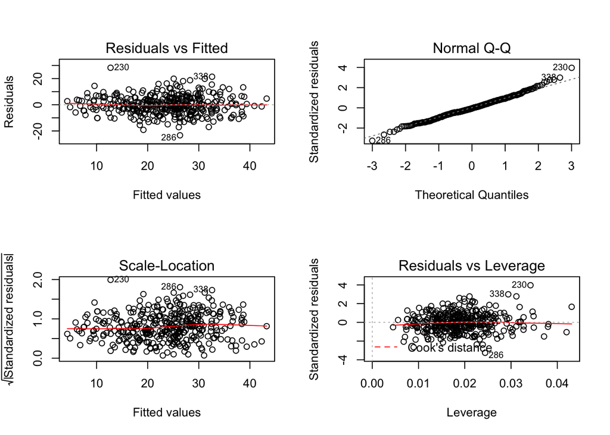

```
##    Min. 1st Qu.  Median    Mean 3rd Qu.    Max.
##   4.951  17.003  24.371  23.113  28.787  38.405
```

Our second linear model is also significant at a 95% confidence level with p-value < 0.05. The second model performs slightly worse with an R-sq value of 0.53. This model was also applied to both the training and testing set. A summary of the predicted values from the testing set are as follows: 4.9511804, 17.0027334, 24.3708327, 23.1129784, 28.7867483, 38.404611

## Score Conclusion

Game Day Scenarios

|  | Rams | Patriots |
| --- | --- | --- |
| **Group 1: Standard NFL Game Stats** |  |  |
| Offensive Yards: High Defensive Yards: low | 40.55 | 39.21 |
| Offensive Yards: High Defensive Yards: High | 36.47 | 36.72 |
| Offensive Yards: Low Defensive Yards: Low | 20.27 | 23.06 |
| Offensive Yards: Low Defensive Yards: High | 16.19 | 20.57 |
| Standard NFL Game Stats Model Scenarios Average | 28.37 | 29.89 |
| Model 1 RMSE | 6.51 | NA |
| **Group 2: Engineered Performance Metrics** |  |  |
| Offense Performance: High Defense Performance: High | 33.55 | 34.76 |
| Offense Performance: High Defense Performance: Low | 38.63 | 37.80 |
| Offense Performance: Low Defense Performance: High | 20.72 | 26.05 |
| Offense Performance: Low Defense Performance: Low | 25.81 | 29.08 |
| Performance Metric Model Scenarios Average | 29.68 | 31.92 |
| Model 2 RMSE | 7.15 | NA |
| Overall Scenario Average | 29.03 | 30.91 |
| Overall RMSE | 6.83 | NA |

# Conclusion

I used two different linear models, both employing similar statistics that are either directly related or calculated from basic NFL game starts like Passing Yards or Rush Yards. I used both a training and testing set for both models to produce predicted values. From there, I ran separate scenarios for potential game outcomes. There we four separate scenarios for both the Los Angeles Rams and the New England Patriots:

- Good offensive day and good defensive day
- Good offensive day and bad defensive day
- Bad offensive day and good defensive day
- Bad offensive day and bad defensive day

With two models, four scenarios for each team, the average of all eight predicted outcomes was taken and compared between teams. That is the prediction of final score, Patriots: 30.91 to Rams: 29.03 with a RSME of 6.83 points.

This method of calculating scores should be considered to be extremely conservative in nature. By taking the average values of relative “good” and “bad” game scenarios is not taking into account any extraordinary performances by either team.

DISCLAIMER: This is a preliminary report and in no way should be relied on for monetary gain. Secondary analysis recommended.